# Starbucks Drink Nutritions and Analysis

Ngoc Kim Ngan Nguyen 46296913

2022-10-18

# Table of contents

**Nutrition Analysis**

1. Introduction
2. Data
3. Methods
4. Results
5. Conclusion and Discussion
6. References

# Introduction

For this report, I will analyse the beverage nutrition from Starbucks with the ‘starbucks’ and ‘starbucks_raw’ dataset. Both two data set included the information about drinks’ names, size and other nutritions facts.

This report is created to answer two research questions mentioned below:

1. Is there a linear relationship between calories and total fat?
2. Are there any correlation between all nutritions’ values?

# Data

The two datasets are from `TidyTuesday` (PythonCoderUnicorn 2021) and only steamed milk data is omitted for this dataset. Some of the example data will be embed below:

```
## Product_Name Size Milk Whip Serv_Size_mL Calories Total_Fat_g
## 1 brewed coffee - dark roast short 0 0 236 3 0.1
## 2 brewed coffee - dark roast tall 0 0 354 4 0.1
## 3 brewed coffee - dark roast grande 0 0 473 5 0.1
## Saturated_Fat_g Trans_Fat_g Cholesterol_mg Sodium_mg Total_Carbs_g Fiber_g
## 1 0 0 0 5 0 0
## 2 0 0 0 10 0 0
## 3 0 0 0 10 0 0
## Sugar_g Caffeine_mg
## 1 0 130
## 2 0 193
## 3 0 260
```

There are `Milk` and `Whip` columns with strange numeric data which will be explained below:

- `Milk`: `0` - none; `1` - nonfat milk; `2` - 2% milk; `3` - soy milk; `4` - coconut milk; `5` - whole milk
- `Whip`: Whip added or not (binary 0/1)

# Methods

## Calories and total fat

The graph below shown how calories and total fat (g) associate with each others in different range of milk (milk denoted have been written in Data part). There is seem to be having correlation between calories and total fat.

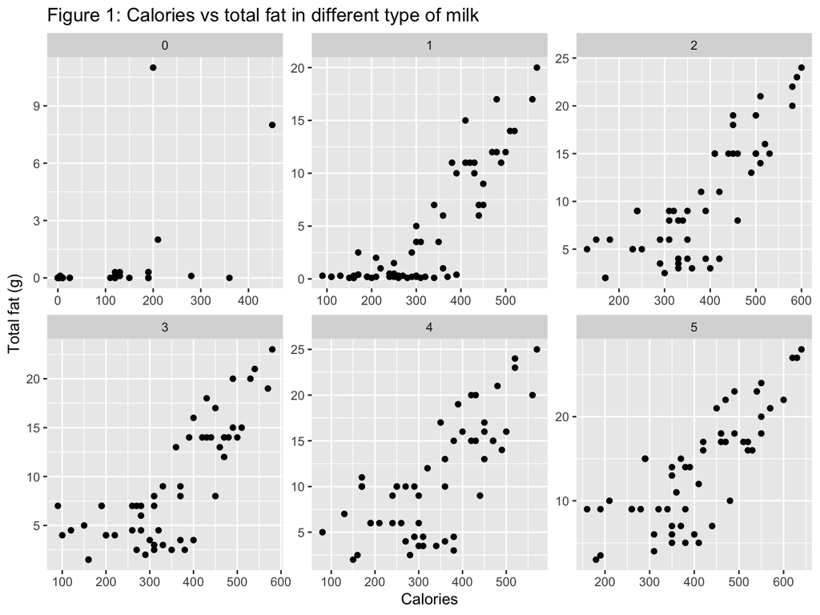

# Results

1. **Linear relationship between calories and total fat:**

```
## Assuming the dataset received in the input have the same set of variable
names
```

```
## HYPOTHESIS
## The null hypothesis H0 is beta=0, and the alternative hypothesis H1 is beta
different from 0. beta is the true slope parameter as in the model total_fat =
alpha + beta calories + epsilon.
```

```
## TEST: Linear regression
```

```
## beta_hat =  0.03498555
```

```
## 95% CI = ( 0.03350272 ,  0.03646839 )
```

```
## t_value =  46.29169
```

```
## df =  1145
```

```
## p_value =  1.562725e-264
```

```
##
## DECISION
```

```
## Reject NULL hypothesis
```

2. **Correlation between all nutritions’ values**

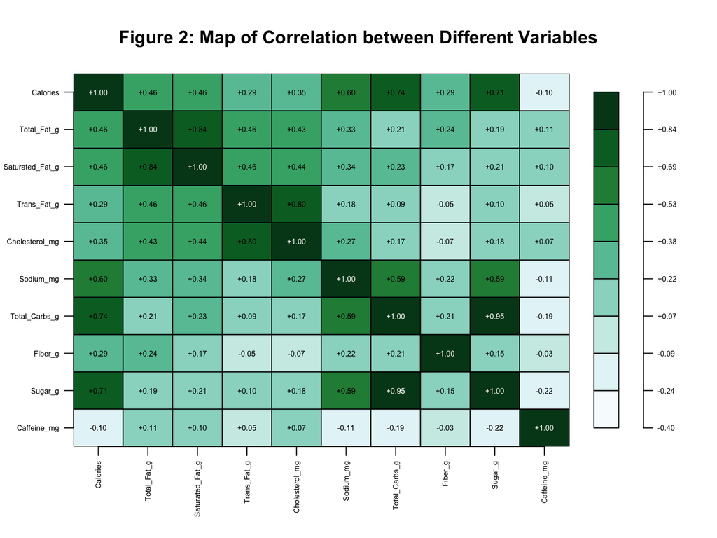

# Conclusions and Discussion

## Conclusion

1. **Linear relationship between calories and total fat:**

```
## CONCLUSION
```

```
## There is evidence that the slope (beta) is different than 0. There is a
significant linear relationship between calories and total_fat. For each
unit-increse in calories, total_fat increases by 0.035.
```

2. **Correlation between all nutritions’ values**

## Discussion

1. **Discussion more of the conclusions**

Question 1 is automatically generated from functions and it needs no longer discussion.

2. **Dataset improvement**

Throughout the process using the aforementioned datasets to write this report, I have some feedbacks on how the dataset could improve on.

1. The clean dataset (`starbucks.csv`) is missed a `Beverage_category` from the raw data (`starbucks_raw.csv`) which prevent me from analyse deeper of each category. It is more practical to analyse the category than specific drinks due to rapidly changes from Starbucks.
2. The dataset is cleaned more than needed i.e. `Milk` and `Whip` column which caused confusing.
3. It can be more practical when combine with sales data to understand more about people nutrition absorption compared to daily human suggested nutrition absorption.

# References

Klinke, Sigbert. 2022. *Plot.matrix: Visualizes a Matrix as Heatmap*. https://CRAN.R-project.org/package=plot.matrix.

Lakna. 2019. *What Is the Difference Between Calories and Cholesterol*. https://pediaa.com/what-is-the-difference-between-calories-and-cholesterol/#Similarities%20Between%20Calories%20and%20Cholesterol.

PythonCoderUnicorn. 2021. *Dataset: Starbucks*. URL: https://github.com/rfordatascience/tidytuesday/blob/master/data/2021/2021-12-21/readme.md.